# Russian brand

allan mutisya

1/16/2021

```r
#  locale workaround
my_locale <- Sys.getlocale("LC_ALL")
Sys.setlocale("LC_ALL", my_locale)
```

```
## [1] ""
```

# Russian Brand

## 1. Defining the question

### a) Specifying the Question

The brand’s Sales and Marketing team would like to understand their customer’s behavior from data that they have collected over the past year. More specifically, they would like to learn the characteristics of customer groups.

### b) Defining the Metric for Success

The analysis will be considered a success when interactive visulizations that tell a good story are achieved. An all-round Exploratory data analysis and a powerful model when is achieved the project will be considered a success.

### c) Understanding the context

The role of the analysis is to come up with recomendations which the sales and marketing team will use to executed in order to identify the fertile areas to first invest on during decision making

### d) Recording the Experimental Design

1. Defining the research question
2. Data Understanding
3. Data cleaning
4. Exploratory Data Analysis
5. Modelling
6. Evaluation
7. Conclusion
8. Recommendations

### e) Data Relevance

The datasets are large enough to be used for Exploratory Data Analysis, thus promising better outcomes.

### f) Reading the Data

```r
# loading the readr library to enable loading the csv dataset
library(readr)

# loading the dataset
brand <- read_csv("C:/Users/ALLANOOH/Documents/moringa/Russian brand/online_shoppers_intention.csv")
head(brand)
```

```
## # A tibble: 6 x 18
##   Administrative Administrative_~ Informational Informational_D~ ProductRelated
##            <dbl>            <dbl>         <dbl>            <dbl>          <dbl>
## 1              0                0             0                0              1
## 2              0                0             0                0              2
## 3              0               -1             0               -1              1
## 4              0                0             0                0              2
## 5              0                0             0                0             10
## 6              0                0             0                0             19
## # ... with 13 more variables: ProductRelated_Duration <dbl>, BounceRates <dbl>,
## #   ExitRates <dbl>, PageValues <dbl>, SpecialDay <dbl>, Month <chr>,
## #   OperatingSystems <dbl>, Browser <dbl>, Region <dbl>, TrafficType <dbl>,
## #   VisitorType <chr>, Weekend <lgl>, Revenue <lgl>
```

## 2. Data Understanding

```r
#checking the columns
ls(brand)
```

```
##  [1] "Administrative"          "Administrative_Duration"
##  [3] "BounceRates"             "Browser"
##  [5] "ExitRates"               "Informational"
##  [7] "Informational_Duration"  "Month"
##  [9] "OperatingSystems"        "PageValues"
## [11] "ProductRelated"          "ProductRelated_Duration"
## [13] "Region"                  "Revenue"
## [15] "SpecialDay"              "TrafficType"
## [17] "VisitorType"             "Weekend"
```

```r
# checking the structure of the dataset
str(brand)
```

```
## tibble [12,330 x 18] (S3: spec_tbl_df/tbl_df/tbl/data.frame)
##  $ Administrative         : num [1:12330] 0 0 0 0 0 0 0 1 0 0 ...
##  $ Administrative_Duration: num [1:12330] 0 0 -1 0 0 0 -1 -1 0 0 ...
##  $ Informational          : num [1:12330] 0 0 0 0 0 0 0 0 0 0 ...
##  $ Informational_Duration : num [1:12330] 0 0 -1 0 0 0 -1 -1 0 0 ...
##  $ ProductRelated         : num [1:12330] 1 2 1 2 10 19 1 1 2 3 ...
##  $ ProductRelated_Duration: num [1:12330] 0 64 -1 2.67 627.5 ...
##  $ BounceRates            : num [1:12330] 0.2 0 0.2 0.05 0.02 ...
##  $ ExitRates              : num [1:12330] 0.2 0.1 0.2 0.14 0.05 ...
##  $ PageValues             : num [1:12330] 0 0 0 0 0 0 0 0 0 0 ...
##  $ SpecialDay             : num [1:12330] 0 0 0 0 0 0 0.4 0 0.8 0.4 ...
##  $ Month                  : chr [1:12330] "Feb" "Feb" "Feb" "Feb" ...
##  $ OperatingSystems       : num [1:12330] 1 2 4 3 3 2 2 1 2 2 ...
##  $ Browser                : num [1:12330] 1 2 1 2 3 2 4 2 2 4 ...
##  $ Region                 : num [1:12330] 1 1 9 2 1 1 3 1 2 1 ...
##  $ TrafficType            : num [1:12330] 1 2 3 4 4 3 3 5 3 2 ...
##  $ VisitorType            : chr [1:12330] "Returning_Visitor" "Returning_Visitor" "Returning_Visitor" "Returning_Visitor" ...
##  $ Weekend                : logi [1:12330] FALSE FALSE FALSE FALSE TRUE FALSE ...
##  $ Revenue                : logi [1:12330] FALSE FALSE FALSE FALSE FALSE FALSE ...
##  - attr(*, "spec")=
##   .. cols(
##   ..   Administrative = col_double(),
##   ..   Administrative_Duration = col_double(),
##   ..   Informational = col_double(),
##   ..   Informational_Duration = col_double(),
##   ..   ProductRelated = col_double(),
##   ..   ProductRelated_Duration = col_double(),
##   ..   BounceRates = col_double(),
##   ..   ExitRates = col_double(),
##   ..   PageValues = col_double(),
##   ..   SpecialDay = col_double(),
##   ..   Month = col_character(),
##   ..   OperatingSystems = col_double(),
##   ..   Browser = col_double(),
##   ..   Region = col_double(),
##   ..   TrafficType = col_double(),
##   ..   VisitorType = col_character(),
##   ..   Weekend = col_logical(),
##   ..   Revenue = col_logical()
##   .. )
```

The dataset is comprised of:

1. numeric, character and logical datatypes.
2. 12330 obs. of 18 variables as the dataset shape

```r
# checking for unique values for the type of visitor variable

unique(brand$VisitorType)
```

```
## [1] "Returning_Visitor" "New_Visitor"       "Other"
```

## 3. Data cleaning

```r
library(caret)
dmy <- dummyVars(" ~ .", data = brand, fullRank = T)
brand_1 <- data.frame(predict(dmy, newdata = brand))
```

```r
# checking for the null values

sum(is.na(brand))
```

```
## [1] 112
```

```r
# dropping the duplicated values
brand_3 <- na.omit(brand)

# checking if the null values have been removed
sum(is.na(brand_3))
```

```
## [1] 0
```

```r
# checking for the duplicated values
sum(duplicated(brand_3))
```

```
## [1] 117
```

We will retain the duplicated valus since there is no strong background to drop them.

```r
# picking the cartegorical variables
df <- subset(brand, select = -c(Month, VisitorType, Revenue, Weekend) )
df
```

```
## # A tibble: 12,330 x 14
##    Administrative Administrative_~ Informational Informational_D~ ProductRelated
##             <dbl>            <dbl>         <dbl>            <dbl>          <dbl>
##  1              0                0             0                0              1
##  2              0                0             0                0              2
##  3              0               -1             0               -1              1
##  4              0                0             0                0              2
##  5              0                0             0                0             10
##  6              0                0             0                0             19
##  7              0               -1             0               -1              1
##  8              1               -1             0               -1              1
##  9              0                0             0                0              2
## 10              0                0             0                0              3
## # ... with 12,320 more rows, and 9 more variables:
## #   ProductRelated_Duration <dbl>, BounceRates <dbl>, ExitRates <dbl>,
## #   PageValues <dbl>, SpecialDay <dbl>, OperatingSystems <dbl>, Browser <dbl>,
## #   Region <dbl>, TrafficType <dbl>
```

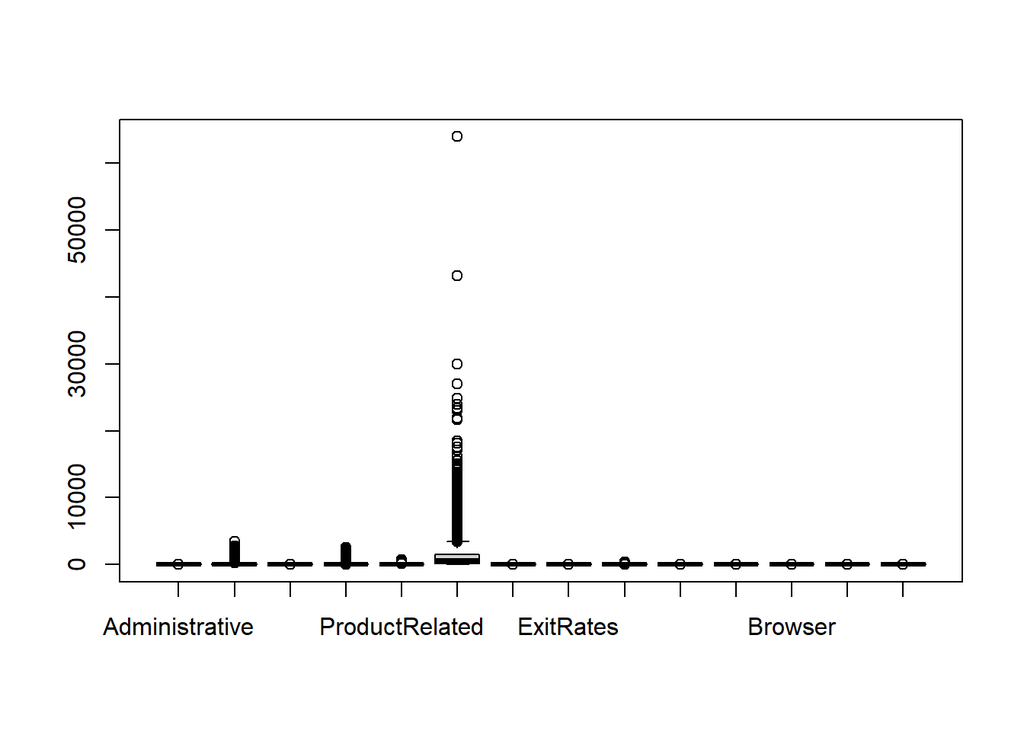

```r
# checking for the outliers
OutVals = boxplot(df)$out
```

The outliers will be retained.

## 4. Exploratory data Analysis

```r
# getting the descriptive statistics of the dataset for each variable
summary(brand_3)
```

```
##  Administrative   Administrative_Duration Informational
##  Min.   : 0.000   Min.   :  -1.00         Min.   : 0.000
##  1st Qu.: 0.000   1st Qu.:   0.00         1st Qu.: 0.000
##  Median : 1.000   Median :   8.00         Median : 0.000
##  Mean   : 2.318   Mean   :  80.91         Mean   : 0.504
##  3rd Qu.: 4.000   3rd Qu.:  93.50         3rd Qu.: 0.000
##  Max.   :27.000   Max.   :3398.75         Max.   :24.000
##  Informational_Duration ProductRelated   ProductRelated_Duration
##  Min.   :  -1.00        Min.   :  0.00   Min.   :   -1.0
##  1st Qu.:   0.00        1st Qu.:  7.00   1st Qu.:  185.0
##  Median :   0.00        Median : 18.00   Median :  599.8
##  Mean   :  34.51        Mean   : 31.76   Mean   : 1196.0
##  3rd Qu.:   0.00        3rd Qu.: 38.00   3rd Qu.: 1466.5
##  Max.   :2549.38        Max.   :705.00   Max.   :63973.5
##   BounceRates         ExitRates         PageValues        SpecialDay
##  Min.   :0.000000   Min.   :0.00000   Min.   :  0.000   Min.   :0.0000
##  1st Qu.:0.000000   1st Qu.:0.01429   1st Qu.:  0.000   1st Qu.:0.0000
##  Median :0.003119   Median :0.02512   Median :  0.000   Median :0.0000
##  Mean   :0.022152   Mean   :0.04300   Mean   :  5.896   Mean   :0.0615
##  3rd Qu.:0.016684   3rd Qu.:0.05000   3rd Qu.:  0.000   3rd Qu.:0.0000
##  Max.   :0.200000   Max.   :0.20000   Max.   :361.764   Max.   :1.0000
##     Month           OperatingSystems    Browser           Region
##  Length:12316       Min.   :1.000    Min.   : 1.000   Min.   :1.000
##  Class :character   1st Qu.:2.000    1st Qu.: 2.000   1st Qu.:1.000
##  Mode  :character   Median :2.000    Median : 2.000   Median :3.000
##                     Mean   :2.124    Mean   : 2.358   Mean   :3.148
##                     3rd Qu.:3.000    3rd Qu.: 2.000   3rd Qu.:4.000
##                     Max.   :8.000    Max.   :13.000   Max.   :9.000
##   TrafficType    VisitorType         Weekend         Revenue
##  Min.   : 1.00   Length:12316       Mode :logical   Mode :logical
##  1st Qu.: 2.00   Class :character   FALSE:9451      FALSE:10408
##  Median : 2.00   Mode  :character   TRUE :2865      TRUE :1908
##  Mean   : 4.07
##  3rd Qu.: 4.00
##  Max.   :20.00
```

#### a) Administrative_Duration

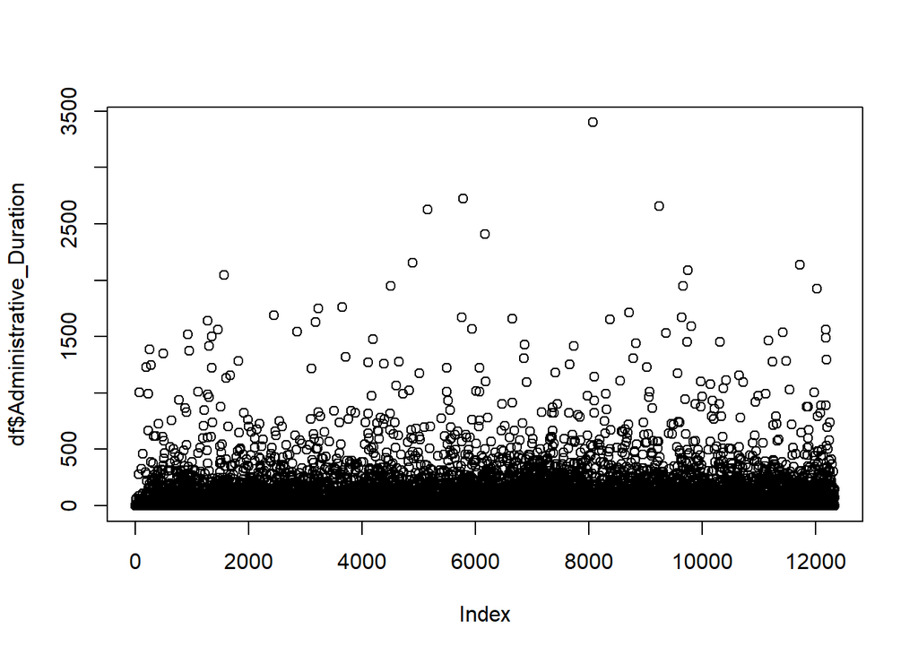

```r
# plotting for the daily time spend on site
scatter.smooth(df$Administrative_Duration)
```

#### b) Informational_Duration

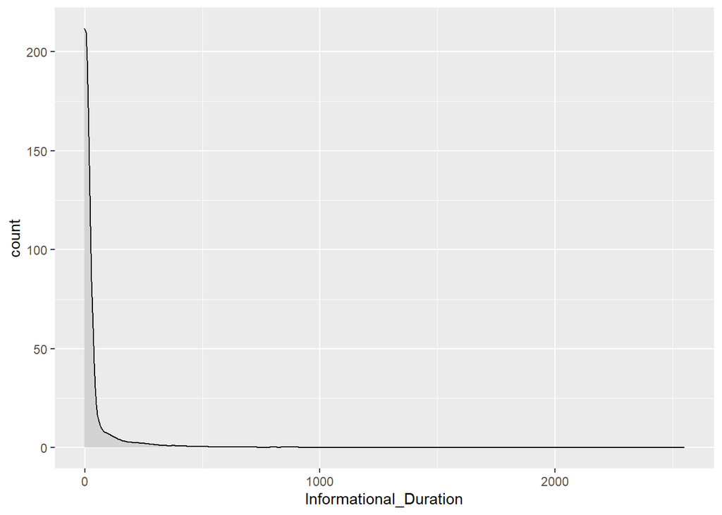

```r
# plotting for the  Informational_Duration
a <- ggplot(df, aes(x = Informational_Duration))
a + geom_density(aes(y = ..count..), fill = "lightgray") +
  geom_vline(aes(xintercept = mean(Informational_Duration)),
             linetype = "dashed", size = 0.6,
             color = "#FC4E07")
```

#### c) Revenue

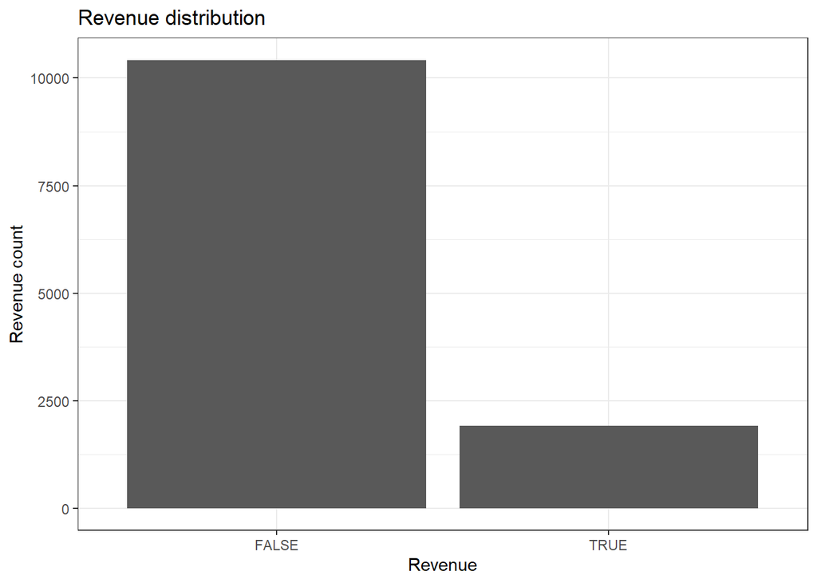

```r
# plotting for the Revenue distribution
ggplot(brand, aes(x = Revenue)) +
  geom_bar() + theme_bw() +
  labs(y = "Revenue count", x = "Revenue", title = "Revenue distribution")
```

Most distribution is on the False.

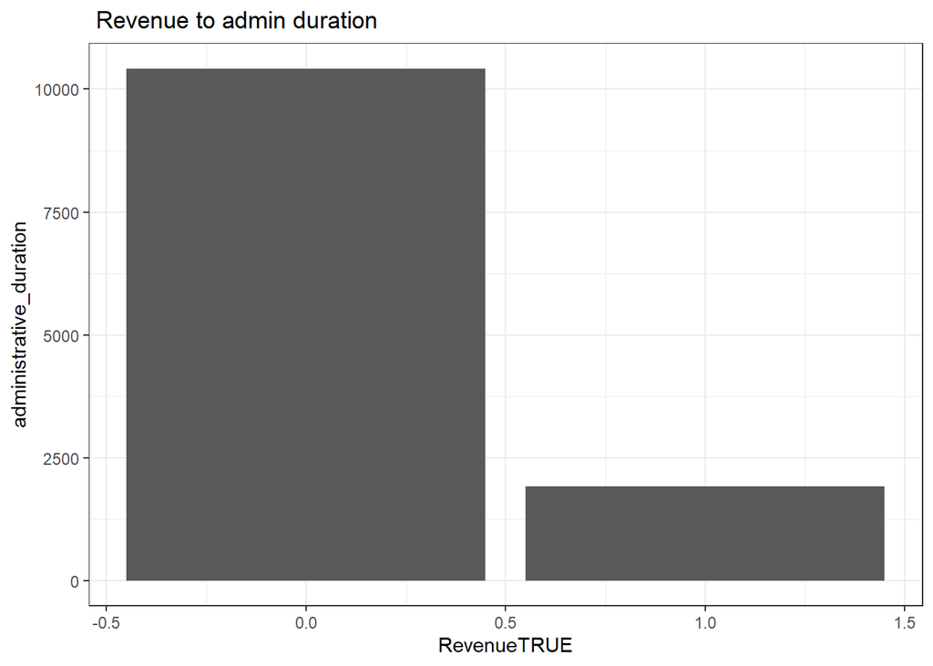

```r
ggplot(brand_1, aes(x = RevenueTRUE, fill = Administrative_Duration)) +
  theme_bw() + geom_bar() +
  labs(y = "administrative_duration", title = " Revenue to admin duration")
```

## 5. Modelling

### K-means clustering

```r
# Preprocessing the dataset
data <- na.omit(brand_1)
x <- subset(data, select = -c(RevenueTRUE) )
y <- data[, "RevenueTRUE"]
head(x)
```

```
##   Administrative Administrative_Duration Informational Informational_Duration
## 1              0                       0             0                      0
## 2              0                       0             0                      0
## 3              0                      -1             0                     -1
## 4              0                       0             0                      0
## 5              0                       0             0                      0
## 6              0                       0             0                      0
##   ProductRelated ProductRelated_Duration BounceRates ExitRates PageValues
## 1              1                0.000000  0.20000000 0.2000000          0
## 2              2               64.000000  0.00000000 0.1000000          0
## 3              1               -1.000000  0.20000000 0.2000000          0
## 4              2                2.666667  0.05000000 0.1400000          0
## 5             10              627.500000  0.02000000 0.0500000          0
## 6             19              154.216667  0.01578947 0.0245614          0
##   SpecialDay MonthDec MonthFeb MonthJul MonthJune MonthMar MonthMay MonthNov
```

[output cut: 20 more lines]

```r
# Previewing the class column
# ---
#
head(y)
```

```
## [1] 0 0 0 0 0 0
```

```r
## Applying the K-means clustering algorithm with no. of centroids(k)=3

model <- kmeans(x,3)

# Previewing the no. of records in each cluster
#
model$size
```

```
## [1]   207 10134  1975
```

```r
# Getting the value of cluster center datapoint value(3 centers for k=3)
# ---
#
model$centers
```

```
##   Administrative Administrative_Duration Informational Informational_Duration
## 1       7.439614               295.36489     2.7487923              266.72309
## 2       1.821985                62.10943     0.3275113               19.98624
## 3       4.325063               154.87748     1.1741772               84.67262
##   ProductRelated ProductRelated_Duration BounceRates  ExitRates PageValues
## 1      236.10628              10886.1744 0.005939756 0.01968831   4.521370
## 2       18.63173                577.3255 0.025411677 0.04763612   5.511318
## 3       77.72962               3355.1075 0.007128234 0.02167056   8.013634
##   SpecialDay   MonthDec    MonthFeb   MonthJul  MonthJune   MonthMar  MonthMay
## 1 0.03091787 0.08695652 0.000000000 0.05314010 0.04347826 0.04347826 0.1062802
## 2 0.06421946 0.14426682 0.017268601 0.03443852 0.02427472 0.16814683 0.2853760
## 3 0.05073418 0.12506329 0.004556962 0.03645570 0.01670886 0.09164557 0.2273418
##    MonthNov   MonthOct   MonthSep OperatingSystems  Browser   Region
## 1 0.5603865 0.02415459 0.04347826         2.149758 2.309179 2.584541
## 2 0.2091968 0.04440497 0.03720150         2.121275 2.367772 3.170022
## 3 0.3858228 0.04759494 0.03139241         2.136203 2.310380 3.094177
##   TrafficType VisitorTypeOther VisitorTypeReturning_Visitor WeekendTRUE
## 1    3.618357      0.004830918                    0.9903382   0.2512077
## 2    4.149891      0.007894217                    0.8344188   0.2348530
## 3    3.710380      0.002025316                    0.9498734   0.2192405
```

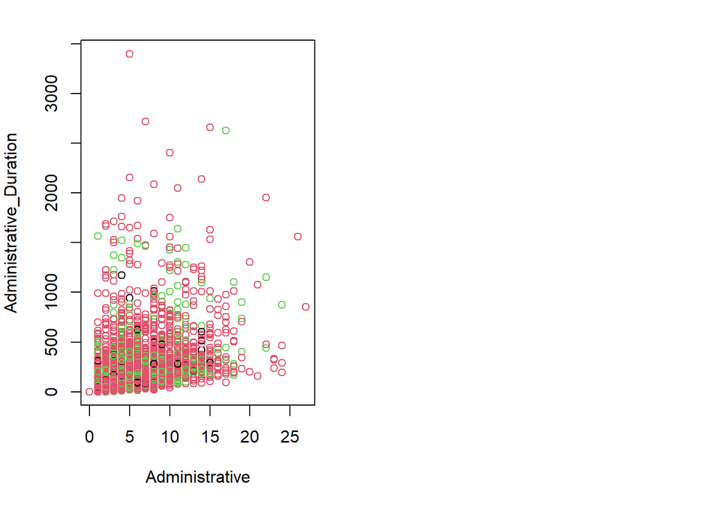

```r
# Visualizing the  clustering results
# ---
#
par(mfrow = c(1,2), mar = c(5,4,2,2))

# Plotting to see how administrative and administrative_duration.R data points have been distributed in clusters
# ---
#
plot(brand_1[,1:2], col = model$cluster)
```

```r
library(class)
table(model$cluster, y)
```

```
##    y
##        0    1
##   1  137   70
##   2 8792 1342
##   3 1479  496
```

### hierarchical cluster analysis

```r
# we start by scaling the data using the R function scale() as follows
df <- scale(data)
head(df)
```

```
##   Administrative Administrative_Duration Informational Informational_Duration
## 1     -0.6975533              -0.4574578    -0.3966145             -0.2450294
## 2     -0.6975533              -0.4574578    -0.3966145             -0.2450294
## 3     -0.6975533              -0.4631119    -0.3966145             -0.2521304
## 4     -0.6975533              -0.4574578    -0.3966145             -0.2450294
## 5     -0.6975533              -0.4574578    -0.3966145             -0.2450294
## 6     -0.6975533              -0.4574578    -0.3966145             -0.2450294
##   ProductRelated ProductRelated_Duration BounceRates  ExitRates PageValues
## 1     -0.6914734              -0.6247671  3.67247746  3.2352400 -0.3173633
## 2     -0.6689966              -0.5913358 -0.45743910  1.1745443 -0.3173633
## 3     -0.6914734              -0.6252895  3.67247746  3.2352400 -0.3173633
## 4     -0.6689966              -0.6233742  0.57504004  1.9988226 -0.3173633
## 5     -0.4891823              -0.2969835 -0.04444744  0.1441964 -0.3173633
## 6     -0.2868911              -0.5442099 -0.13139305 -0.3800157 -0.3173633
##   SpecialDay   MonthDec MonthFeb   MonthJul  MonthJune   MonthMar   MonthMay
```

[output cut: 27 more lines]

```r
# We now use the R function hclust() for hierarchical clustering

# First we use the dist() function to compute the Euclidean distance between observations,
# d will be the first argument in the hclust() function dissimilarity matrix


d <- dist(df, method = "euclidean")

# We then hierarchical clustering using the Ward's method
# ---
#
res.hc <- hclust(d, method = "ward.D2" )
```

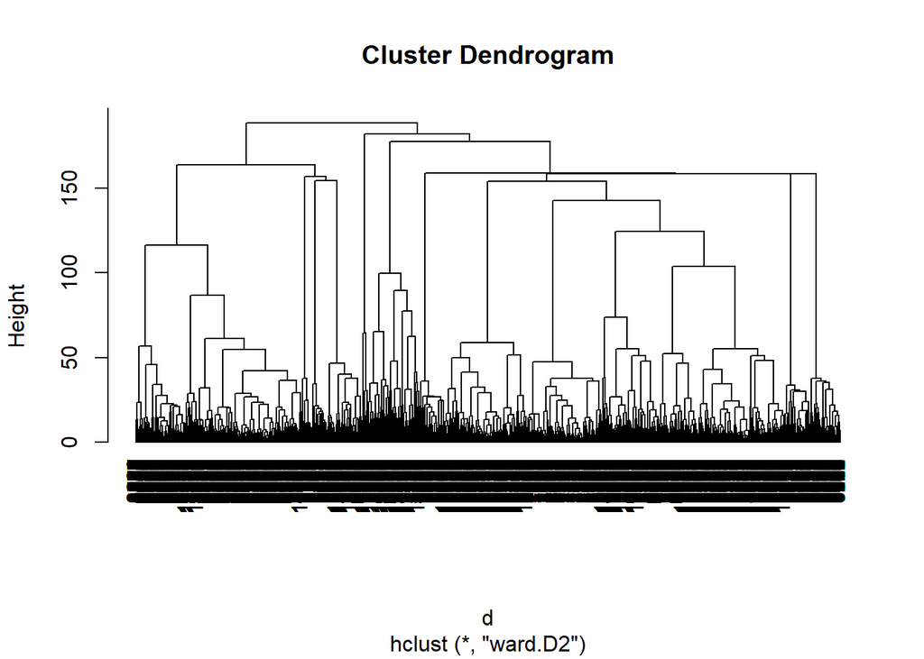

```r
# Lastly, we plot the obtained dendrogram
# ---
#
plot(res.hc, cex = 0.9, hang = -4)
```